# Auswertung eines Datensatzes

Arbeitsblatt 2 · Principles of Data Visualization - HS2026

| **Autor:** | Schmid, Elio, FH Graubünden, MSc Data Visualization |
| --- | --- |
| **Dozentin:** | PD Dr. rer. nat. Helena Jambor |
| **Ort, Datum:** | Bern, 05.10.2026 |

# 1 Datensatz

## 1.1 Was beschreibt der Datensatz?

Es werden zwei Datensätze untersucht. Darin werden die Anzahl Schritte pro Tag und der dazugehörige BMI einer Person aufgeführt. Einmal werden die Daten für Jungen dargestellt und einmal für Mädchen. Insgesamt handelt es sich um 1786 Beobachtungen. Davon entfallen 921 auf Jungen und 865 auf Mädchen.Bei der Anzahl Schritten bewegen sich die Beobachtungen zwischen 0/301 (Jungen/Mädchen) und 15’000 (Jungen & Mädchen). Der BMI bewegt sich zwischen 15/15.7 (Jungen/Mädchen) und 32 (Jungen & Mädchen).

## 1.2 Gibt es einen Unterschied zwischen den mittleren Schrittzahlen der Jungen und Mädchen

Der Mittelwert der Mädchen und Jungen unterscheidet sich absolut. Mädchen gehen im Mittel 8014 Schritte und Jungen 6891, was einem Unterschied von 1123 entspricht.

| Gender | n | Mittelwert | Standardabweichung | Median |
| --- | --- | --- | --- | --- |
| Male | 921 | 6891 | 3674 | 7130 |
| Female | 865 | 8014 | 3255 | 7894 |

Statistisch gesehen unterscheiden sich die Mittelwerte ebenso. Auf Basis der Annahme, dass die Daten einer Normalverteilung folgen, wurde ein T-Test auf Mittelwertgleichheit durchgeführt. Die Hypothese wurde auf dem 95%-Konfidenzintervall verworfen.

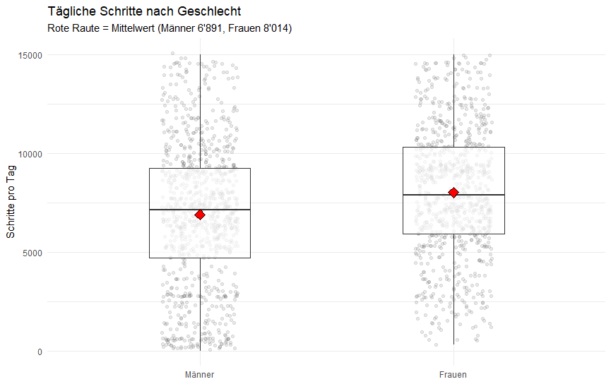

Boxplot mit Streuung der Schrittzahl und Mittelwert

## 1.3 Gibt es eine positive Korrelation zwischen der Schrittzahl und dem BMI bei Jungen?

Eine positive Korrelation zwischen der Schrittzahl und dem BMI bei Jungen gibt es in dem Sinne nicht, als dass man sagen kann, dass bei höherer Schrittzahl der BMI zunimmt (statistisch würde dies einem positiven Zusammenhang entsprechen). Es ist eher das Gegenteil der Fall, dass die Daten negativ Korrelieren, was in dem Sinne eine positive Aussage sein könnte. Nämlich je mehr Schritte desto niedriger der BMI. Wichtig zu erwähnen ist, dass diese Feststellung noch nicht einer Ursache-Wirkungs-Beziehung entspricht. Es wäre falsch zu behaupten, dass der BMI sinkt, je mehr Schritte ein Junge macht.

## 1.4 Welche weiteren Schlüsse können ihr bilden, oder Hypothesen aufstellen?

- Gibt es einen Unterschied zwischen den mittleren BMI der Mädchen und Jungen?

# 2 Beschreibung und Botschaft der Visualisierung

## 2.2 Was war die beabsichtigte Botschaft?

# 3 Optimierung der Visualisierung

## 3.2 Skizze der Verbesserungsidee

[figure not shown]

# 4 Wie kann die Wirkung sein? Welche Verantwortung tragen Datenvisualisierende?